# Problem Set 1

## Differently Distributed Data

In this section we’ll take a look at the distributions of a couple different kinds of data.

#### 4. Height measurments

Download and read in the *fatherson.csv.bz2* data from Canvas and answer the following:

1. Looking just at the `fheight` column, how many observations do we have? How many null/missing values? How many unreasonable or invalid values? *Note: The `fheight` column contains the heights of fathers in this dataset, measured in centimeters.*
2. Compute the mean, median, and standard deviation of the `fheight` column. Just by looking at these values, do you believe our data is spread out or skewed? Why or why not?
3. Plot a histogram of this data. Add vertical lines to indicate the mean and median.
4. What does the distribution of this data tell you about height as a natural phenomena?

```r
# Load the data
fatherson <- read_csv("fatherson.csv.bz2")
# a. Examine the fheight column
num_observations <- length(fatherson$fheight)
num_missing <- sum(is.na(fatherson$fheight))
# Define reasonable height range for adult males (e.g., 140-220 cm)
num_unreasonable <- sum(fatherson$fheight < 140 | fatherson$fheight > 220, na.rm = TRUE)

print(paste("Number of observations in fheight column:", num_observations))
```

```
[1] "Number of observations in fheight column: 1078"
```

```r
print(paste("Number of missing values in fheight column:", num_missing))
```

```
[1] "Number of missing values in fheight column: 0"
```

```r
print(paste("Number of unreasonable values in fheight column:", num_unreasonable))
```

```
[1] "Number of unreasonable values in fheight column: 0"
```

```r
# b. Calculate statistics
mean_height <- mean(fatherson$fheight, na.rm = TRUE)
median_height <- median(fatherson$fheight, na.rm = TRUE)
sd_height <- sd(fatherson$fheight, na.rm = TRUE)

print(paste("Mean father height:", round(mean_height, 2), "cm"))
```

```
[1] "Mean father height: 171.93 cm"
```

```r
print(paste("Median father height:", round(median_height, 2), "cm"))
```

```
[1] "Median father height: 172.1 cm"
```

```r
print(paste("Standard deviation of father height:", round(sd_height, 2), "cm"))
```

```
[1] "Standard deviation of father height: 6.97 cm"
```

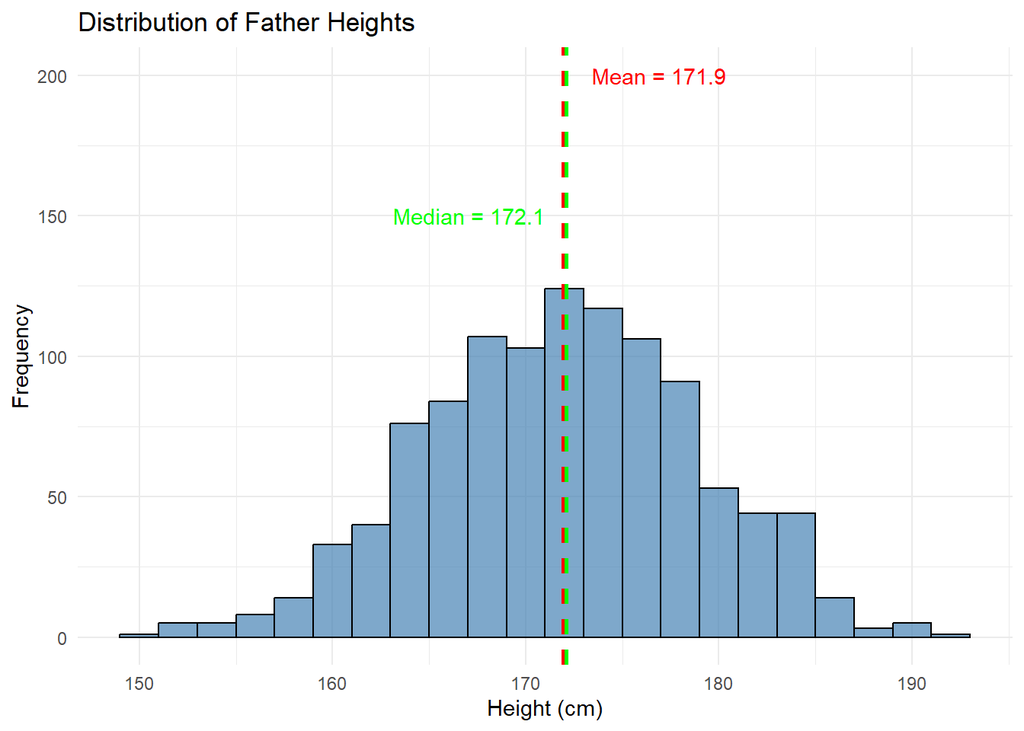

```r
# c. Plot histogram with mean and median lines
ggplot(fatherson, aes(x = fheight)) +
  geom_histogram(binwidth = 2, fill = "steelblue", color = "black", alpha = 0.7) +
  geom_vline(aes(xintercept = mean_height), color = "red", linetype = "dashed", linewidth = 1) +
  geom_vline(aes(xintercept = median_height), color = "green", linetype = "dashed", linewidth = 1) +
  labs(title = "Distribution of Father Heights",
       x = "Height (cm)",
       y = "Frequency") +
  theme_minimal() +
  annotate("text", x = mean_height + 5, y = 200, label = paste("Mean =", round(mean_height, 1)), color = "red") +
  annotate("text", x = median_height - 5, y = 150, label = paste("Median =", round(median_height, 1)), color = "green")
```

#### 5. Financial transactions

Download and read in the *account-transactions.csv.bz2* data from Canvas and answer the following:

1. Looking just at the `amount` column, how many observations do we have? How many null/missing values? How many unreasonable or invalid values? *Note: The `amount` column contains transaction amounts in US dollars.*
2. Compute the mean, median, and standard deviation of the `amount` column. Just by looking at these values, do you believe our data is spread out or skewed? Why or why not?
3. Plot a histogram of this data. Add vertical lines to indicate the mean and median.
4. What does the distribution of this data tell you about transaction amounts?

```r
# Load the financial transactions data
account_transactions <- read_csv("account-transactions.csv.bz2")
# a. Examine the amount column
num_observations_amount <- length(account_transactions$amount)
num_missing_amount <- sum(is.na(account_transactions$amount))
# Consider transactions outside a reasonable range (e.g., > $100,000) as potentially unreasonable
# This threshold would depend on the context of the transactions
num_unreasonable_amount <- sum(account_transactions$amount < -100000 | account_transactions$amount > 100000, na.rm = TRUE)

print(paste("Number of observations in amount column:", num_observations_amount))
```

```
[1] "Number of observations in amount column: 1657"
```

```r
print(paste("Number of missing values in amount column:", num_missing_amount))
```

```
[1] "Number of missing values in amount column: 0"
```

```r
print(paste("Number of potentially unreasonable values in amount column:", num_unreasonable_amount))
```

```
[1] "Number of potentially unreasonable values in amount column: 0"
```

```r
# b. Calculate statistics
mean_amount <- mean(account_transactions$amount, na.rm = TRUE)
median_amount <- median(account_transactions$amount, na.rm = TRUE)
sd_amount <- sd(account_transactions$amount, na.rm = TRUE)

print(paste("Mean transaction amount: $", round(mean_amount, 2)))
```

```
[1] "Mean transaction amount: $ 89.91"
```

```r
print(paste("Median transaction amount: $", round(median_amount, 2)))
```

```
[1] "Median transaction amount: $ 11.9"
```

```r
print(paste("Standard deviation of transaction amount: $", round(sd_amount, 2)))
```

```
[1] "Standard deviation of transaction amount: $ 368.23"
```

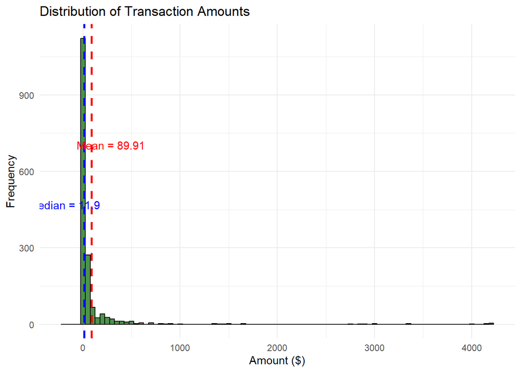

```r
# c. Plot histogram with mean and median lines
ggplot(account_transactions, aes(x = amount)) +
  geom_histogram(binwidth = 50, fill = "darkgreen", color = "black", alpha = 0.7) +
  geom_vline(aes(xintercept = mean_amount), color = "red", linetype = "dashed", linewidth = 1) +
  geom_vline(aes(xintercept = median_amount), color = "blue", linetype = "dashed", linewidth = 1) +
  labs(title = "Distribution of Transaction Amounts",
       x = "Amount ($)",
       y = "Frequency") +
  theme_minimal() +
  annotate("text", x = mean_amount + 200, y = max(table(cut(account_transactions$amount, breaks = 50)))/2,
           label = paste("Mean =", round(mean_amount, 2)), color = "red") +
  annotate("text", x = median_amount - 200, y = max(table(cut(account_transactions$amount, breaks = 50)))/3,
           label = paste("Median =", round(median_amount, 2)), color = "blue")
```

## Random Variables

#### 6. Sampling from data

Download and read in the *titanic.csv.bz2* data from Canvas. We will be treating the `fare` column as if it is a random variable or population we want to sample. For our purposes, let’s assume that all values in `fare` represent the true population and our samples will represent a sampling of that population.

1. Sample 10 values from `fare` 10 times using `sample()` and take the mean of each sample. **BE SURE TO REMOVE NULL/MISSING VALUES** *Hint: A for-loop is the most intuitive way to do this, but there are several methods.*
2. Calculate the overall sampled population mean by taking the mean of the samples you collected. How does it compare to the actual population mean (i.e. the mean of the entire column)
3. Calculate the standard deviation of sample means (i.e. standard error).
4. Plot your sample means as a histogram.
5. Now, increase your number of samples to 1000 and repeat b), c) and d). What happens to your sampled population mean, standard error, and histogram distribution when you increase the number of samples?

```r
# Load the Titanic data
titanic <- read_csv("titanic.csv.bz2")
# a. Sample 10 values from fare 10 times and calculate means
# First, remove missing values from the fare column
fare_clean <- titanic$fare[!is.na(titanic$fare)]

# Initialize vector to store sample means
sample_means_10 <- numeric(10)

# Generate 10 samples of size 10 and calculate their means
set.seed(123) # For reproducibility
for (i in 1:10) {
  sample_i <- sample(fare_clean, 10, replace = TRUE)
  sample_means_10[i] <- mean(sample_i)
}

print("a. Means of 10 samples (each with 10 values):")
```

```
[1] "a. Means of 10 samples (each with 10 values):"
```

```r
print(sample_means_10)
```

```
 [1] 20.68209 12.07334 20.54292 35.10874 57.62499 20.14583 23.30250 19.74958
 [9] 40.77209 21.52292
```

```r
# b. Calculate the sampled population mean and compare to actual population mean
sampled_pop_mean_10 <- mean(sample_means_10)
actual_pop_mean <- mean(fare_clean)

print("b. Comparison of means:")
```

```
[1] "b. Comparison of means:"
```

```r
print(paste("Sampled population mean (10 samples):", round(sampled_pop_mean_10, 2)))
```

```
[1] "Sampled population mean (10 samples): 27.15"
```

```r
print(paste("Actual population mean:", round(actual_pop_mean, 2)))
```

```
[1] "Actual population mean: 33.3"
```

```r
print(paste("Difference:", round(sampled_pop_mean_10 - actual_pop_mean, 2)))
```

```
[1] "Difference: -6.14"
```

```r
# c. Calculate the standard error
standard_error_10 <- sd(sample_means_10)
print("c. Standard error (standard deviation of sample means):")
```

```
[1] "c. Standard error (standard deviation of sample means):"
```

```r
print(round(standard_error_10, 2))
```

```
[1] 13.5
```

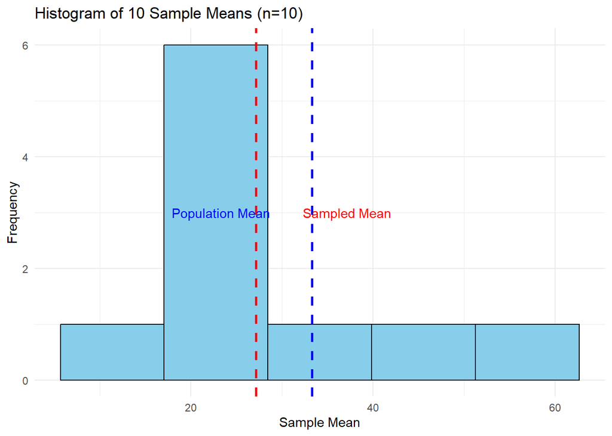

```r
# d. Plot the sample means as a histogram
# Create data frame for ggplot
sample_means_df_10 <- data.frame(means = sample_means_10)

# Create histogram
ggplot(sample_means_df_10, aes(x = means)) +
  geom_histogram(bins = 5, fill = "skyblue", color = "black") +
  geom_vline(aes(xintercept = sampled_pop_mean_10), color = "red", linetype = "dashed", size = 1) +
  geom_vline(aes(xintercept = actual_pop_mean), color = "blue", linetype = "dashed", size = 1) +
  labs(title = "Histogram of 10 Sample Means (n=10)",
       x = "Sample Mean",
       y = "Frequency") +
  theme_minimal() +
  annotate("text", x = sampled_pop_mean_10 + 10, y = 3, label = "Sampled Mean", color = "red") +
  annotate("text", x = actual_pop_mean - 10, y = 3, label = "Population Mean", color = "blue")
```

```r
# e. Increase to 1000 samples and repeat
sample_means_1000 <- numeric(1000)

for (i in 1:1000) {
  sample_i <- sample(fare_clean, 10, replace = TRUE)
  sample_means_1000[i] <- mean(sample_i)
}

# Calculate the sampled population mean
sampled_pop_mean_1000 <- mean(sample_means_1000)
standard_error_1000 <- sd(sample_means_1000)

print("e. Results for 1000 samples:")
```

```
[1] "e. Results for 1000 samples:"
```

```r
print(paste("Sampled population mean (1000 samples):", round(sampled_pop_mean_1000, 2)))
```

```
[1] "Sampled population mean (1000 samples): 33.52"
```

```r
print(paste("Actual population mean:", round(actual_pop_mean, 2)))
```

```
[1] "Actual population mean: 33.3"
```

```r
print(paste("Difference:", round(sampled_pop_mean_1000 - actual_pop_mean, 2)))
```

```
[1] "Difference: 0.23"
```

```r
print(paste("Standard error (1000 samples):", round(standard_error_1000, 2)))
```

```
[1] "Standard error (1000 samples): 16.93"
```

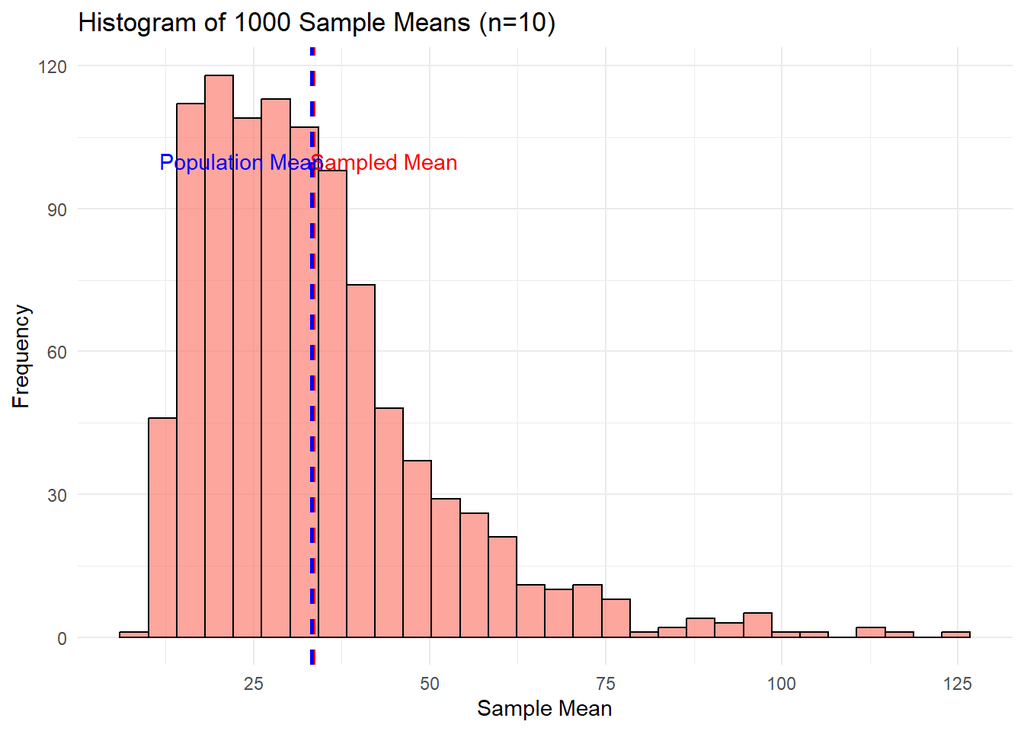

```r
# Create histogram for 1000 samples
sample_means_df_1000 <- data.frame(means = sample_means_1000)

ggplot(sample_means_df_1000, aes(x = means)) +
  geom_histogram(bins = 30, fill = "salmon", color = "black", alpha = 0.7) +
  geom_vline(aes(xintercept = sampled_pop_mean_1000), color = "red", linetype = "dashed", size = 1) +
  geom_vline(aes(xintercept = actual_pop_mean), color = "blue", linetype = "dashed", size = 1) +
  labs(title = "Histogram of 1000 Sample Means (n=10)",
       x = "Sample Mean",
       y = "Frequency") +
  theme_minimal() +
  annotate("text", x = sampled_pop_mean_1000 + 10, y = 100, label = "Sampled Mean", color = "red") +
  annotate("text", x = actual_pop_mean - 10, y = 100, label = "Population Mean", color = "blue")
```